# Exercises 1

Kendra Ferrier

11/30/2018

# Overview

Here is a [link](https://raw.githubusercontent.com/IDPT7810/practical-data-analysis/master/vignettes/problem-set-1.Rmd) to the text of these exercises.

# Question 1

Tidy the `mtcars` data set. Note that car names are rownames in the built-in data, so they need to be moved to their own column prior to tibble conversion.

The tidied data should look like:

```
# A tibble: 352 x 3
name   var value
<chr> <chr> <dbl>
  1         Mazda RX4   mpg  21.0
2     Mazda RX4 Wag   mpg  21.0
3        Datsun 710   mpg  22.8
4    Hornet 4 Drive   mpg  21.4
5 Hornet Sportabout   mpg  18.7
6           Valiant   mpg  18.1
7        Duster 360   mpg  14.3
8         Merc 240D   mpg  24.4
9          Merc 230   mpg  22.8
10          Merc 280   mpg  19.2
# ... with 342 more rows
```

```r
mtcars_wide <- mtcars %>%
  rownames_to_column() %>%
  as_tibble()

mtcars_wide
```

```
## # A tibble: 32 x 12
##    rowname   mpg   cyl  disp    hp  drat    wt  qsec    vs    am  gear
##    <chr>   <dbl> <dbl> <dbl> <dbl> <dbl> <dbl> <dbl> <dbl> <dbl> <dbl>
##  1 Mazda …  21       6  160    110  3.9   2.62  16.5     0     1     4
##  2 Mazda …  21       6  160    110  3.9   2.88  17.0     0     1     4
##  3 Datsun…  22.8     4  108     93  3.85  2.32  18.6     1     1     4
##  4 Hornet…  21.4     6  258    110  3.08  3.22  19.4     1     0     3
##  5 Hornet…  18.7     8  360    175  3.15  3.44  17.0     0     0     3
##  6 Valiant  18.1     6  225    105  2.76  3.46  20.2     1     0     3
##  7 Duster…  14.3     8  360    245  3.21  3.57  15.8     0     0     3
##  8 Merc 2…  24.4     4  147.    62  3.69  3.19  20       1     0     4
##  9 Merc 2…  22.8     4  141.    95  3.92  3.15  22.9     1     0     4
## 10 Merc 2…  19.2     6  168.   123  3.92  3.44  18.3     1     0     4
## # ... with 22 more rows, and 1 more variable: carb <dbl>
```

## Strategy

Use the tidyverse function as_tibble to tidy the mtcars data frame.

## Interpretation

The mtcars data frame is changed from a data frame to a tbl_df.

# Question 2

For each car in the tidy `mtcars` data set, calculate the mean (`mean()`) and variance (`var()`) for each variable. Try using `summarize()` and `summarize_at()` and `summarize_all()`.

```r
mtcars_long <- mtcars_wide %>%
  gather(key, value, -rowname)

mtcars_long %>%
  group_by(key) %>%
  summarize(mean(value), var(value))
```

```
## # A tibble: 11 x 3
##    key   `mean(value)` `var(value)`
##    <chr>         <dbl>        <dbl>
##  1 am            0.406        0.249
##  2 carb          2.81         2.61
##  3 cyl           6.19         3.19
##  4 disp        231.       15361.
##  5 drat          3.60         0.286
##  6 gear          3.69         0.544
##  7 hp          147.        4701.
##  8 mpg          20.1         36.3
##  9 qsec         17.8          3.19
## 10 vs            0.438        0.254
## 11 wt            3.22         0.957
```

## Strategy

Turn the tidied mtcars data frame into a long form data frame.

## Interpretation

Long data frames are better for summary statistics.

# Question 3

Plot `mpg` vs `cyl` for the `mtcars` data set. Which format should you use? The original data set, or the tidied one? Why?

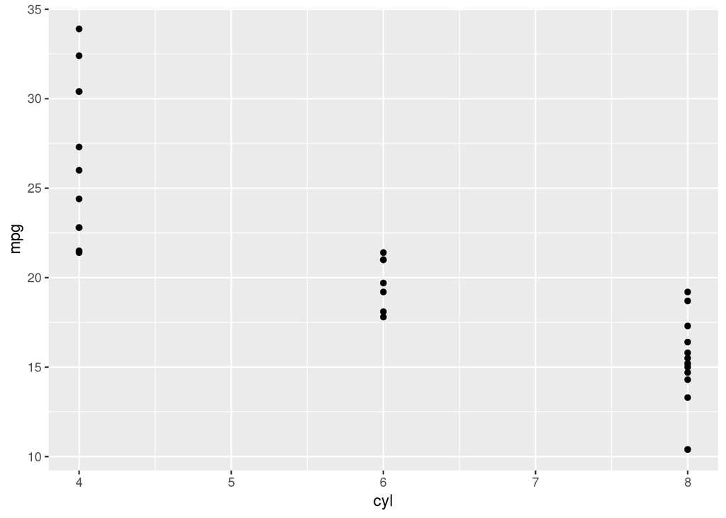

```r
mtcars_wide <- mtcars %>%
  rownames_to_column() %>%
  as_tibble()

mtcars_wide %>%
  ggplot(aes(x = cyl, y = mpg)) +
  geom_point()
```

## Strategy

Use ggplot2 and the tidied wide form of the mtcars data frame.The wide format of a data frame is better for plotting. The tidied version needs to be used versus the original dataset because it puts the data into a standardized structure that is easier to analyze.

## Interpretation

The greater the number of cylendars the lower the mpg.

# Question 4

Using the provided `qpcr` data, plot the changes in gene expression over time. Use **colors** to represent genotypes and **facets** for the different genes. If thats too easy, add error bars (`geom_errorbar()`) to the plot and connect each point with a line (`geom_line()`).

```r
qpcr_data_tidy <- gather(qpcr_data, col, value, -row)
qpcr_names_tidy <- gather(qpcr_names, col, value, -row) %>%
  separate(value, into = c('genotype', 'time', 'gene', 'rt', 'rep'), sep = "_")

qpcr_tidy <- left_join(qpcr_names_tidy, qpcr_data_tidy)  %>%
  filter(rt == "+") %>%
  select(-row, -col, -rt)
```

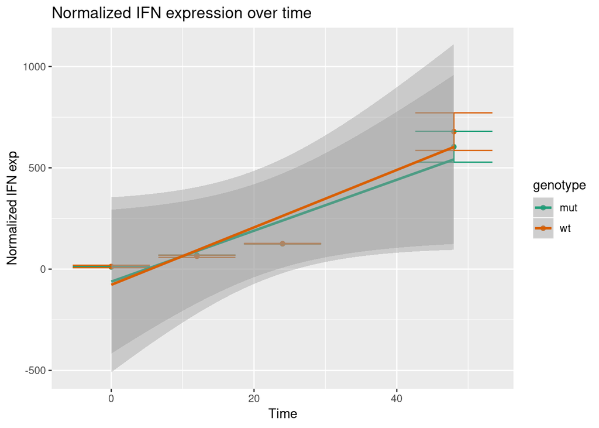

```r
qpcr_plot_dat <- qpcr_tidy %>%
  spread(gene, value) %>%
  mutate(IFN_norm = IFN - ACTIN) %>%
  select(-ACTIN, -IFN) %>%
  group_by(genotype, time) %>%
  summarize(
    IFN_mean = mean(IFN_norm),
    IFN_sd = sd(IFN_norm)
  )

qpcr_plot_dat2 <- qpcr_plot_dat %>%
  mutate(time = as.numeric(time))

ggplot(qpcr_plot_dat2, aes(x= time, y = IFN_mean, color = genotype)) +
  geom_point() +
  scale_color_brewer(palette = "Dark2") +
  geom_errorbar(
    aes(ymax = IFN_mean + IFN_sd,
        ymin = IFN_mean - IFN_sd)) +
  labs(
    title = "Normalized IFN expression over time",
    x = "Time",
    y = "Normalized IFN exp") +
  geom_smooth(method = 'lm')
```

## Strategy

Using the tidyverse package, tidy the qpcr data, then analyze.

## Interpretation

The interferon expression increases over time.